# Are shots predictive of soccer results?

A Stan model for the shooting soccer ability

L.Egidi, F.Pauli, N.Torelli - University of Trieste, Italy

StanCon Helsinki, 29-31 August 2018

# Introduction

Predicting the outcome of a soccer match is the subject of much debate, and several models based on different assumptions have been proposed for modeling the numbers of goals scored by two competing teams:

- double Poisson models (Baio and Blangiardo 2010; Maher 1982; Rue and Salvesen 2000; Egidi, Pauli, and Torelli 2018);
- joint bivariate Poisson models accounting for a (positive) goals’ correlation (Karlis and Ntzoufras 2003);
- negative binomial models accounting for goals’ overdispersion.

In this case study we adopt a different perspective and propose a Bayesian hierarchical model consisting of three nested multiple outcomes: **number of scores**, **number of shots on target** and **number of total shots**. We model the number of scores and the number of shots on target with two binomial distributions respectively, whereas the total shots follow a negative binomial distributon. Our dataset consists of nine seasons of the English Premier League (EPL): eight seasons—from 2008/2009 to 2015/2016, 3040 matches—represent the train set, whereas the nineth season, 2016/2017 (with the remaining 380 matches), is our test set, used for out-of sample prediction.

We fit the model in $\mathsf{Stan}$ and we analyze the output using $\mathsf{R}$.

# Model

Here, $\mathbf{y}_n=(y_{n1}, y_{n2})$ denotes the vector of observed scores, where $y_{n1}$ and $y_{n2}$ are the numbers of goals scored by the home team and by the away team in the $n$-th match of the dataset, respectively. Let $\mathbf{s}_n=(s_{n1}, s_{n2})$ denote the shots on the target and $\mathbf{w}_{n}=(w_{n1}, w_{n2})$ the total number of shots, respectively. For each match $n$, the data information is represented by the joint vector $(\mathbf{y}, \mathbf{s}, \mathbf{w})$. The total number of teams considered across the seasons is $T=34$. In the model specification below, the nested indexes $h(n), a(n)=1,\ldots, T$ and $\tau(n)=1,\ldots,9$ identify the home team, the away team and the season $\tau$ associated with the $n$-th game, respectively. The hierarchical model for the scores and the shots is then specified as follows:

$$\begin{align}
\begin{split}
y_{n1}& \sim \mathsf{Binomial}(s_{n1}, p_{h(n),\ \tau(n)}) \\
y_{n2}& \sim \mathsf{Binomial}(s_{n2}, q_{a(n),\ \tau(n)}) \\
s_{n1} & \sim \mathsf{Binomial}(w_{n1}, u_{h(n)})\\
s_{n2} & \sim \mathsf{Binomial}(w_{n2}, v_{a(n)})\\
w_{nj}| \theta_{nj} &\sim \mathsf{NegBinomial}(\theta_{nj}, \phi), \ \ j=1,2.\\
%s_{n1} & \perp s_{n2} | \theta_{n1}, \theta_{n2}.
\end{split}
\label{eq:model}
\end{align}$$
An inverse logit specification considering the attack and the defense abilities of the competing teams across the seasons is proposed for both the *conversion probabilities* $p$ and $q$:

$$\begin{align}
\begin{split}
p_{h(n),\ \tau(n)} & = \mbox{logit}^{-1}(\mu+att_{h(n),\ \tau(n)}+def_{a(n) ,\ \tau(n)})\\
q_{a(n),\ \tau(n)} & = \mbox{logit}^{-1}(att_{a(n),\ \tau(n)}+def_{h(n),\ \tau(n) }).
\end{split}
\label{eq:conv_prob}
\end{align}$$
The attack and defence parameters are assumed to to be dynamic (Owen 2011) and to follow two Gaussian processes:

$$\begin{align}
\begin{split}
att_{\cdot,\tau} \sim & \mathsf{GP}(\mu_{att}(\tau), k(\tau)),\\
def_{\cdot, \tau} \sim & \mathsf{GP}(\mu_{def}(\tau), k(\tau)),
\end{split}
\label{eq:att_def}
\end{align}$$
with mean functions $\mu_{att}( \tau)=0,\ \mu_{def}(\tau)=0$, and covariance function with generic element $k(\tau)_{i,j}= \exp \{ -(\tau_{i}-\tau_{j})^{2} \}+0.1$. As motivated in the literature, a `zero-sum’ identifiability constraint within each season is required; thus, we assume: $\sum_{t=1}^{T} att_{t ,\tau}=0,\ \sum_{t=1}^{T}def_{t,\tau}=0, \tau=1,\ldots \mathcal{T}$.

The *shots’ precision probabilities* $u$ and $v$ are given a $\mathsf{Beta}$ distribution with hyperparameters $\delta,\epsilon$, whereas the *shots rates* $\theta_{n1}, \theta_{n2}$ are assigned a $\mathsf{Gamma}$ distribution with hyperparameters $\alpha,\beta$, :

$$\begin{align}
u_{h(n}) &\sim \mathsf{Beta}(\delta_{h(n)},\epsilon_{h(n)}), \ v_{a(n)} \sim \mathsf{Beta}(\delta_{a(n)},\epsilon_{a(n)}) \\
\theta_{n1} &\sim \mathsf{Gamma}(\alpha_{h(n)},\beta_{h(n)}), \ \theta_{n2} \sim \mathsf{Gamma}(\alpha_{a(n)},\beta_{a(n)}).
\end{align}$$
The model is completed by the elicitation of weakly informative priors for the home effect parameter $\mu$, the overdispersion parameter $\phi$, and the hyperparameters $\alpha,\beta,\delta,\epsilon$:

$$\begin{align}
\mu \sim \mathsf{Normal}(0,1)\\
\phi \sim \mathsf{Normal}(0,1)\\
\alpha \sim \mathsf{Normal}(0,5)\\
\beta \sim \mathsf{Normal}(0,5)\\
\delta \sim \mathsf{Normal}(0,5)\\
\epsilon \sim \mathsf{Normal}(0,5)
\end{align}$$

#Reading data

EPL data have been downloaded from the website https://football-data.co.uk. Once you save the $\mathsf{.csv}$ files in your computer, the function `import_data()`is needed for importing them in the $\mathsf{R}$ environment; `PL` is the full dataset, consisting of the nine seasons (3420 rows and 16 columns). After importing data, we rename the main quantities. Among the others, `teams` identifies the teams, `score1`, `score2` identify the home teams and away teams goals, respectively. `kicks1`, `kicks2` are the total shots, whereas `kicks1_target`, `kicks2_target` denote the kicks on target. `team_1`, `team_2` denote the home team and the away team index, respectively. As mentioned above, we use the first eight seasons as training set—with length `ngames_train`—and the nineth as test set—with length `ngames_test`.

```r
#load required packages
library(rstan)
library(readr)
library(ggplot2)
library(dplyr)
library(reshape2)
library(shinystan)
library(bayesplot)
library(kableExtra)
library(loo)
library(matrixStats)

#my directory, where .csv files are stored
mydir <- getwd()
#global function for importing several seasons
import_data <- function(season){
  season <- read_csv(paste(mydir, "/", season,".csv", sep=""))
  pl <- cbind( season$HomeTeam, season$AwayTeam,
           season$FTHG, season$FTAG, season$FTR,
           season$HS, season$AS, season$HST,season$AST,
           season$HY, season$AY, season$HR, season$AR,
           season$B365H, season$B365D, season$B365A)
           return(list(pl=pl, season=season))
}
#data concatenation
seasons_string <- c("PL08-09", "PL09-10", "PL10-11",
                    "PL11-12","PL12-13", "PL13-14",
                    "PL14-15", "PL15-16", "PL16-17" )

#full dataset
PL <- rbind(import_data("PL08-09")$pl,
           import_data("PL09-10")$pl,
           import_data("PL10-11")$pl,
           import_data("PL11-12")$pl,
           import_data("PL12-13")$pl,
           import_data("PL13-14")$pl,
           import_data("PL14-15")$pl,
           import_data("PL15-16")$pl,
           import_data("PL16-17")$pl)

#season index
season_or <- rep(1:9, each=380)
#number of season
nseason   <- length(unique(season_or))
season_time <- c(1:nseason)
#teams for all the nine seasons
teams_matrix <- matrix(NA, nseason, 20)
   for (i in 1:length(seasons_string)){
        launch <- import_data(seasons_string[i])
        teams_matrix[i,] <- unique(launch$pl[,1])
 }
teams   <- unique( as.vector(t(teams_matrix)))
PL16_17 <-  import_data("PL16-17")
teams16_17 <- unique(PL16_17$season$HomeTeam)
teams16_17_index <- match(teams16_17, teams)
nteams <- length(teams)
#total games
ngames_tot   <- length(PL[,1])
#test set games
ngames_test  <- 380
#train set games
ngames_train <- ngames_tot-ngames_test
season_train <- season_or[1:ngames_train]
#team index, scores and kicks
team1             <- match (as.vector(PL[,1])[1:ngames_train], teams)
score1            <- as.numeric(as.vector(PL[,3])[1:ngames_train])
team2             <- match (as.vector(PL[,2])[1:ngames_train], teams)
score2            <- as.numeric(as.vector(PL[,4])[1:ngames_train])
kicks1            <- as.vector(as.numeric(PL[1:ngames_train,6]))
kicks2            <- as.vector(as.numeric(PL[1:ngames_train,7]))
kicks1_target     <- as.vector(as.numeric(PL[1:ngames_train,8]))
kicks2_target     <- as.vector(as.numeric(PL[1:ngames_train,9]))
score1_prev       <- as.numeric(as.vector(PL[,3])[(ngames_train+1):ngames_tot])
score2_prev       <- as.numeric(as.vector(PL[,4])[(ngames_train+1):ngames_tot])
team1_prev        <- match (as.vector(PL[,1])[(ngames_train+1):ngames_tot], teams)
team2_prev        <- match (as.vector(PL[,2])[(ngames_train+1):ngames_tot], teams)
season_prev       <- season_or[(ngames_train+1):ngames_tot]

# correction for both the shots on target and the total shots:
# when the number of shots on target (total shots) is minor than
# the number of scores (shots on target), the binomial distribution
# above stucks: for simplicity, we assume that the number of
# shots on target (total shots) is always greater or equal than
# the number of scores (shots on target).

kicks1_target[(1:ngames_train)[score1>kicks1_target]]=score1[ (1:ngames_train)[score1>kicks1_target]]
kicks2_target[(1:ngames_train)[score2>kicks2_target]]=score2[ (1:ngames_train)[score2>kicks2_target]]
kicks1[(1:ngames_train)[kicks1<kicks1_target]]=kicks1_target[(1:ngames_train)[kicks1<kicks1_target]]
kicks2[(1:ngames_train)[kicks2<kicks2_target]]=kicks2_target[(1:ngames_train)[kicks2<kicks2_target]]
```

# Stan code

We provide here the self-explanatory $\mathsf{Stan}$ code, saved as $\mathsf{shots.stan}$. The `generated quantities` block contains both in-sample and out-of-sample replications.

```stan
data {
  int N;                                  // number of matches
  int nseason;                            // number of seasons
  int season[N];                          // season index
  int score_home[N];                      // home scores
  int score_away[N];                      // away scores
  int Shots_home[N];                      // home shots on target
  int Shots_away[N];                      // away total shots on target
  int Tot_Shots_home[N];                  // home total shots
  int Tot_Shots_away[N];                  // away total shots
  int nteams;                             // number of teams
  int teams_home[N];                      // team home index
  int teams_away[N];                      // team away index
  int N_prev;                             // number of predicted matches
  int teams_home_prev[N_prev];            // team home predicted index
  int teams_away_prev[N_prev];            // team away predicted index
  int season_prev[N_prev];                // season predicted index
  int season_time[nseason];
  }
 parameters {
  real mu;                                // home effect parameter
  real<lower=0> phi;                      // overdispersion total shots parameter
  vector<lower=0>[nteams] alpha;          // total shots shape
  vector<lower=0>[nteams] beta;           // total shots rate
  vector<lower=0>[nteams] delta;          // beta shape 1
  vector<lower=0>[nteams] epsilon;        // beta shape 2
  matrix[nseason, nteams] att_raw;        // raw attack ability
  matrix[nseason, nteams] def_raw;        // raw defense ability
  vector<lower=0>[N] theta_home;          // home total shots rate
  vector<lower=0>[N] theta_away;          // away total shots rate
}
 transformed parameters{
  matrix[nseason, nteams] att;            // attack abilities
  matrix[nseason, nteams] def;            // defense abilities
  cov_matrix[nseason] Sigma_att;          // Gaussian process attack cov. funct.
  cov_matrix[nseason] Sigma_def;          // Gaussian process defense cov.funct.
  matrix[nseason, nteams] mu_att;         // attack hyperparameter
  matrix[nseason, nteams] mu_def;         // defense hyperparameter
  matrix<lower=0, upper=1>[nteams,nseason-1] p;   // conversion home probabilities
  matrix<lower=0, upper=1>[nteams,nseason-1] q;   // conversion away probabilities

  p = rep_matrix(0.2, nteams, nseason-1);
  q = rep_matrix(0.2, nteams, nseason-1);


  // Gaussian process covariance functions
   for (i in 1:(nseason)){
     for (j in 1:(nseason)){
       Sigma_att[i, j] = exp(-pow(season_time[i] - season_time[j], 2))
       + (i == j ? 0.1 : 0.0);
       Sigma_def[i, j] = exp(-pow(season_time[i] - season_time[j], 2))
                   + (i == j ? 0.1 : 0.0);
     }}

  // Sum-to-zero constraint for attack/defense parameters
  att[1]=att_raw[1]-mean(att_raw[1]);
  def[1]=def_raw[1]-mean(def_raw[1]);
   for (t in 2:nseason){
      att[t]=att_raw[t]-mean(att_raw[t]);
      def[t]=def_raw[t]-mean(def_raw[t]);
     }

  // Lagged prior mean for attack/defense parameters
   for (t in 2:(nseason)){
     mu_att[1]=rep_row_vector(0,nteams);
     mu_att[t]=rep_row_vector(0,nteams);
     //att[t-1];
     mu_def[1]=rep_row_vector(0,nteams);
     mu_def[t]=rep_row_vector(0,nteams);
     //def[t-1];
     }

  // Conversion probabilities
   for (n in 1:N){
     p[teams_home[n], season[n]]=inv_logit(mu+att[season[n], teams_home[n]]
                                    +def[season[n], teams_away[n]]);
     q[teams_away[n], season[n]]=inv_logit(att[season[n], teams_away[n]]
                                    +def[season[n], teams_home[n]]);
     }
}
 model{
  // Priors
  target+=normal_lpdf(phi|0,1);
  target+=normal_lpdf(alpha |0,5);
  target+=normal_lpdf(beta |0,5);
  target+=normal_lpdf(delta |0,5);
  target+=normal_lpdf(epsilon |0,5);

   for (h in 1:(nteams)){
     att_raw[,h]~multi_normal(mu_att[,h], Sigma_att);
     def_raw[,h]~multi_normal(mu_def[,h], Sigma_def);
   }

  // Likelihood
   for (n in 1:N){
     target+= binomial_lpmf(score_home[n] |  Shots_home[n],
                            p[teams_home[n],season[n]]);
     target+= binomial_lpmf(score_away[n] |  Shots_away[n],
                            q[teams_away[n], season[n]]);
     target+= beta_binomial_lpmf(Shots_home[n] |  Tot_Shots_home[n],
                                 delta[teams_home[n]],epsilon[teams_home[n]]);
     target+= beta_binomial_lpmf(Shots_away[n] |  Tot_Shots_away[n],
                                 delta[teams_away[n]],epsilon[teams_away[n]]);
     target+=gamma_lpdf(theta_home[n]|alpha[teams_home[n]],beta[teams_home[n]]);
     target+=gamma_lpdf(theta_away[n]|alpha[teams_away[n]],beta[teams_away[n]]);
      }

  target+= neg_binomial_2_lpmf(Tot_Shots_home|theta_home, phi );
  target+= neg_binomial_2_lpmf(Tot_Shots_away|theta_away, phi);
}
 generated quantities{
  vector[N] log_lik;
  int score_home_rep[N];        // in-sample replication for home scores
  int score_away_rep[N];        // in-sample replications for away scores
  int Shots_home_rep[N];        // in-sample replications for home shots on t.
  int Shots_away_rep[N];        // in-sample replications for away shots on t.
  int Tot_Shots_home_rep[N];    // in-sample replications for home total shots
  int Tot_Shots_away_rep[N];    // in-sample replications for away total shots
  int score_home_prev[N_prev];  // out-of-sample replications for home scores
  int score_away_prev[N_prev];  // out-of-sample replications for away scores
  int Shots_home_prev[N_prev];  // out-of-sample replications for home shots on t.
  int Shots_away_prev[N_prev];  // out-of-sample replications for away shots on t.
  int Tot_Shots_home_prev[N_prev];  // out-of-sample repl. for home total shots
  int Tot_Shots_away_prev[N_prev];  // out-of-sample repl. for away total shots
  vector<lower=0>[N_prev] theta_home_prev;   // predicted home shooting rate
  vector<lower=0>[N_prev] theta_away_prev;   // predicted away shooting rate
  vector<lower=0, upper=1>[nteams] p_prev;   // pred. conversion home probabilities
  vector<lower=0, upper=1>[nteams] q_prev;   // pred. conversion away probabilities

    for (n in 1:N){
      Tot_Shots_home_rep[n]=neg_binomial_2_rng(theta_home[n], phi);
      Tot_Shots_away_rep[n]=neg_binomial_2_rng(theta_away[n], phi);
      Shots_home_rep[n]=beta_binomial_rng(Tot_Shots_home_rep[n],
                        delta[teams_home[n]],epsilon[teams_home[n]]);
      Shots_away_rep[n]=beta_binomial_rng(Tot_Shots_away_rep[n],
                        delta[teams_away[n]],epsilon[teams_away[n]]);
      score_home_rep[n]=binomial_rng(Shots_home_rep[n],
                                      p[teams_home[n], season[n]]);
      score_away_rep[n]=binomial_rng(Shots_away_rep[n],
                                      q[teams_away[n], season[n]]);
      log_lik[n] =binomial_lpmf(score_home[n] |  Shots_home[n],
                                p[teams_home[n],season[n]])+
                  binomial_lpmf(score_away[n] |  Shots_away[n],
                                q[teams_away[n], season[n]]);
                  }

  // p_prev and q_prev initialization
   p_prev=p[,nseason-1];
   q_prev=q[,nseason-1];

    for (n in 1:N_prev){
      p_prev[teams_home_prev[n]]=p[teams_home_prev[n], nseason-1];
      q_prev[teams_away_prev[n]]=q[teams_away_prev[n], nseason-1];
      theta_home_prev[n]=gamma_rng(alpha[teams_home_prev[n]],
                                    beta[teams_home_prev[n]]);
      theta_away_prev[n]=gamma_rng(alpha[teams_away_prev[n]],
                                    beta[teams_away_prev[n]]);
      Tot_Shots_home_prev[n]=neg_binomial_2_rng(theta_home_prev[n], phi);
      Tot_Shots_away_prev[n]=neg_binomial_2_rng(theta_away_prev[n], phi);
      Shots_home_prev[n]=beta_binomial_rng(Tot_Shots_home_prev[n],
                  delta[teams_home_prev[n]],epsilon[teams_home_prev[n]]);
      Shots_away_prev[n]=beta_binomial_rng(Tot_Shots_away_prev[n],
                  delta[teams_away_prev[n]],epsilon[teams_away_prev[n]]);
      score_home_prev[n]=binomial_rng(Shots_home_prev[n],
                                        p_prev[teams_home_prev[n]]);
      score_away_prev[n]=binomial_rng(Shots_away_prev[n],
                                        q_prev[teams_away_prev[n]]);
        }
}
```

# Fitting the model

We fit the model running four chains each of length 1000 HMC iterations. The Gelman-Rubin statistic $\hat{R}\le 1.1$ for all the parameters.

```r
# data
shots_data <- list(N=ngames_train, N_prev=ngames_test, score_home=score1,
                   score_away=score2, Shots_home=kicks1_target,
                   Shots_away=kicks2_target, Tot_Shots_home=kicks1,
                   Tot_Shots_away=kicks2, nteams=nteams,
                   teams_home=team1, teams_away=team2,
                   teams_home_prev=team1_prev, teams_away_prev=team2_prev,
                   season=season_or[1:ngames_train], season_prev=season_prev,
                   nseason=nseason,
                   season_time=season_time)

# fit stan model
mod_shots_stan <- stan(file="shots.stan", data=shots_data,  iter = 1000,
                       chains = 4, cores = 4, seed = 1)
# save the Stan fit result (mod_shots_stan in the document) in a new file called fit.RData.
save(mod_shots_stan, file = "fit.RData")
# load("fit.RData")

#  extract posterior output
sims <- extract(mod_shots_stan)
```

# Parameters estimates

## Evolution of team abilities across the seasons

Higher values for the attack parameters are associated with a greater propensity to convert the shots on target in goals; conversely, lower values for the defense correspond to a better ability to not concede goals. The figure below displays the posterior medians for parameters $att$ (orange solid lines) and $def$ (black solid lines) along with the 50% credible bars across the different seasons; it is worth noting that the model above does not account for any *relegation* system. However, the dynamic assumption allows for estimating the above mentioned latent abilities for all the teams, even those not partecipating to the EPL in some seasons—such as Middlesbrough, Swansea, Watford and many others.

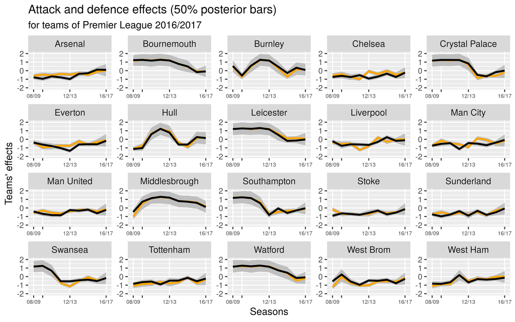

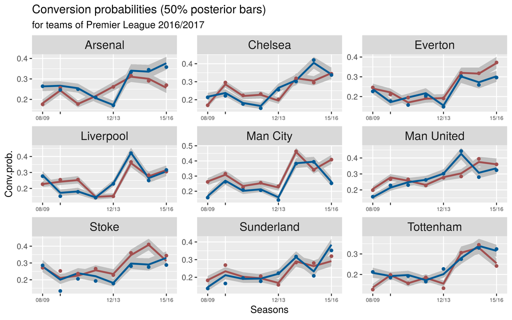

## Shots rates

The total shots consist of the shots on target and all those out-of-target attempts—such as long-distance shots, last-minute shots—that often are not really correlated with the actual attack ability. However, massive shooting is a necessary condition for increasing the winning probability: as shown in the figure below, the teams associated with the highest average shots rates—both home and away—correspond to those that dominated the EPL in the last years: Manchester City, Arsenal, Chelsea, Tottenham and Liverpool. Each team shows a greater shooting activity when plays at its home stadium. The figure displays the verage shots rates, $\bar{\theta}_1, \bar{\theta}_2$ for home teams (red bars) and away teams (blue bars) respectively.

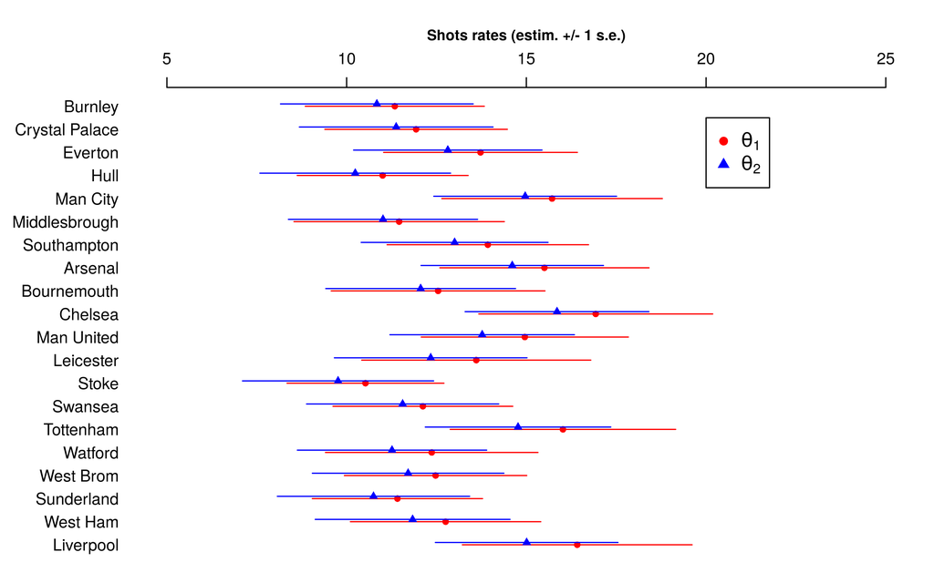

# Model checking

We use now the replicated data defined in the `generated quantities` block for assessing the global goodness of fit of the proposed model. Thus, we draw simulated values $y^{rep}$ from the joint predictive distribution of replicated data:

$$\begin{equation*}
p(y^{rep}|y) = \int_{\Theta} p({y}^{rep}, \theta|y) d\theta= \int_{\Theta} p(\theta|y)p({y}^{rep}|\theta) d\theta.
\label{posterior_predicitve_1}
\end{equation*}$$

It is worth noting that the symbol $y^{rep}$ used here is conceptually different from the symbol $\tilde{y}$ used in the next section. The former is just a replication of $y$, the latter is any future observable unknown value. The figure below displays the posterior medians (red tails) for the score difference $y_{n1}-y_{n2}$ along with the posterior 95% intervals (light yellow ribbon) and the 50% posterior (dark yellow ribbon), plotted against the observed ordered score differences (blue points). We may note that the model calibration is quite good for the 95% uncertainty intervals—95.1% of the observed score differences fall inside the corresponding intervals—whereas the model calibration may not be considered equally decent for the 50% uncertinty intervals, since only 33% of the observed differences fall inside.

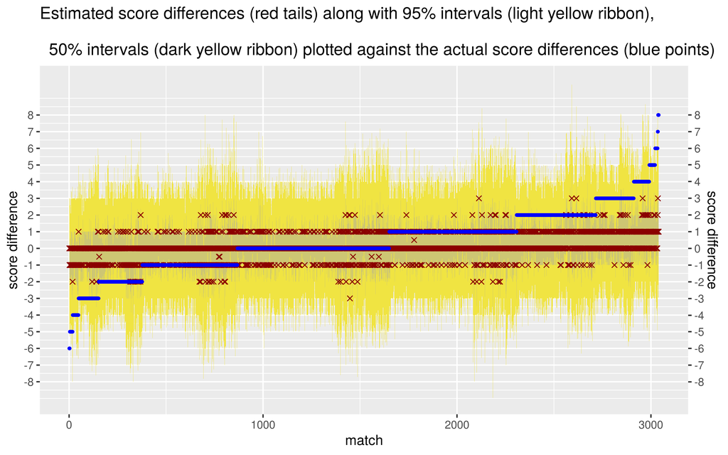

```r
diff_gol=score1-score2
diff_gol_rep=sims$score_home_rep-sims$score_away_rep

scd <- diff_gol
scd_sims <- diff_gol_rep

scd_hat <- colMedians(scd_sims)
scd_se <- sqrt(colVars(scd_sims))
# 95% credible intervals
alpha <- 0.95;
scd_ub <- colQuantiles(scd_sims, probs = 1-(1-alpha)/2)
scd_lb <- colQuantiles(scd_sims, probs = (1-alpha)/2)
ci95 <- sum(scd < scd_ub & scd_lb<scd)/ngames_train
# 50% credible intervals
alpha <- 0.5;
scd_ub2 <- colQuantiles(scd_sims, probs = 1-(1-alpha)/2)
scd_lb2 <- colQuantiles(scd_sims, probs = (1-alpha)/2)
ci50 <- sum(scd < scd_ub2 & scd_lb2<scd)/ngames_train
# ordered quantiles
sort_scd <- scd[order(scd)]
sort_scd_hat <- scd_hat[order(scd)]
sort_scd_se <- scd_se[order(scd)]
sort_scd_ub <- scd_ub[order(scd)]
sort_scd_lb <- scd_lb[order(scd)]
sort_scd_ub2 <- scd_ub2[order(scd)]
sort_scd_lb2 <- scd_lb2[order(scd)]
df <- data.frame(list(scd = sort_scd, scd_hat = sort_scd_hat, scd_se = sort_scd_se,
  scd_ub = sort_scd_ub, scd_lb = sort_scd_lb,
  scd_ub2 = sort_scd_ub2, scd_lb2 = sort_scd_lb2))

ggplot(df, aes(x = c(1:ngames_train))) +
  geom_ribbon(aes(ymin = scd_lb,
    ymax = scd_ub),
    fill="#F0E442") +
  geom_ribbon(aes(ymin = scd_lb2,
    ymax = scd_ub2),
    fill="khaki3") +
  geom_point(aes(y=scd_hat),colour="darkred",shape=4) +
  geom_point(aes(y=scd), size = 0.7, col="blue") +
  scale_x_continuous(name="match") +
  scale_y_continuous(name="score difference",
    breaks = c(-8,-7,-6,-5,-4,-3,-2,-1,0,1,2,3,4,5,6,7,8),
    sec.axis = dup_axis()) +
  ggtitle("Estimated score differences (red tails) along with 95% intervals (light yellow ribbon),
    \n  50% intervals (dark yellow ribbon) plotted against the actual score differences (blue points)")
```

# Model comparison: LOOIC

```r
double_poi_stan <- stan(file="double_poisson.stan", data=scores_data,
                        iter = 2000, chains = 4, cores = 4, seed = 1)

log_lik1 <- extract_log_lik(mod_shots_stan)
loo1 <- loo(log_lik1)

log_lik2 <- extract_log_lik(double_poi_stan)
loo2 <- loo(log_lik2)
```

|  | LOOIC | LOOIC_SE |
| --- | --- | --- |
| Double Poisson | 1133.8 | 25.1 |
| Shots model | 1132.3 | 30.0 |

There is only a slight improvement in the looic due to the adoption of the shots model instead of the double Poisson model.

# Posterior prediction probabilities

Making predictions is the hottest task for a sport statistician. We may achieve this goal in several ways: we may predict single match results, the final number of rank points, the relegated teams, etc. This section may be seen as a sort of visualization tutorial for the posterior ouputs. All we need are posterior probabilities for future matches, obtained through HMC samples of future scores $\tilde{y}_{m1}, \tilde{y}_{m2}$, corresponding to `score_home_prev` and `score_away_prev` respectively, and saved in the `sims` objects. Let $\tilde{y}$ be a generic unknown observable. Its distribution is then conditional on the observed $y$,

$$\begin{equation*}
p(\tilde{y}|y) = \int_{\Theta} p(\tilde{y}, \theta|y) d\theta= \int_{\Theta} p(\theta|y)p(\tilde{y}|\theta) d\theta,
\label{posterior_predicitve_2}
\end{equation*}$$

where the conditional independence of $y$ and $\tilde{y}$ given $\theta$ is assumed. The first figure below shows the joint posterior probabiities for the goals in one selected future match between Middlesbrough (home team) and Stoke City (away team): darker region are associated with more likely results. The red square corresponds to the observed result.

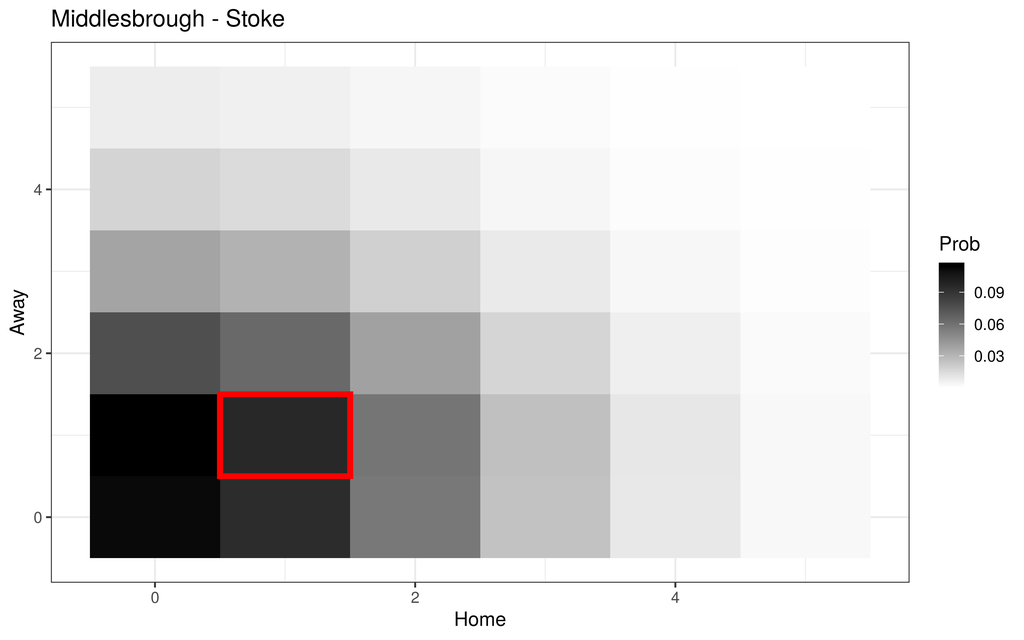

Similarly as before, we may obtain a sort of PP plot for the score differences of the predicted matches, plotting posterior 95% uncertainty intervals (light yellow ribbon), 50% uncertainty intervals (dark yellow ribbon) and posterior medians (red tails) against the actual observed score differences (blue points). Still, the model partially lacks in the 50% calibration, since only 38.6% of the points fall inside the 50% uncertainty interval; however, the calibration for the 95% uncertainty intervals is good, with 95.7% of the observed score differences falling into the intervals.

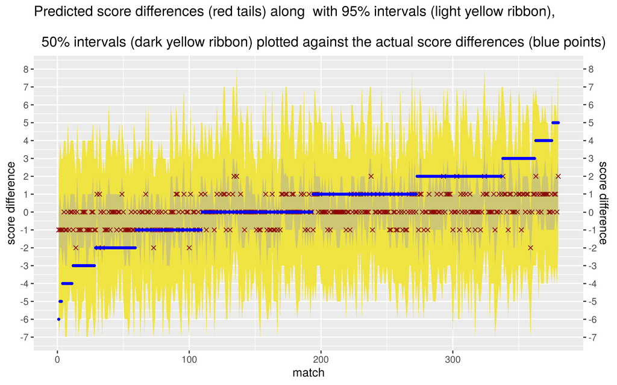

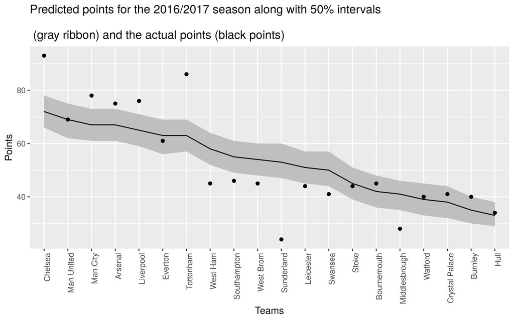

| Team | Prob(1st) | Prob(2nd) | Prob(3rd) | Actual rank | Observed points |
| --- | --- | --- | --- | --- | --- |
| Chelsea | 0.28 | 0.192 | 0.1455 | 1 | 93 |
| Tottenham | 0.0595 | 0.0725 | 0.085 | 2 | 86 |
| Man City | 0.1325 | 0.1365 | 0.1215 | 3 | 78 |

| Team | Prob(1rel) | Prob(2rel) | Prob(3rel) | Actual rank | Observed points |
| --- | --- | --- | --- | --- | --- |
| Hull | 0.1675 | 0.2 | 0.275 | 18 | 34 |
| Middlesbrough | 0.123 | 0.0875 | 0.0775 | 19 | 28 |
| Sunderland | 0.016 | 0.01 | 0.0045 | 20 | 24 |

# Betting strategy

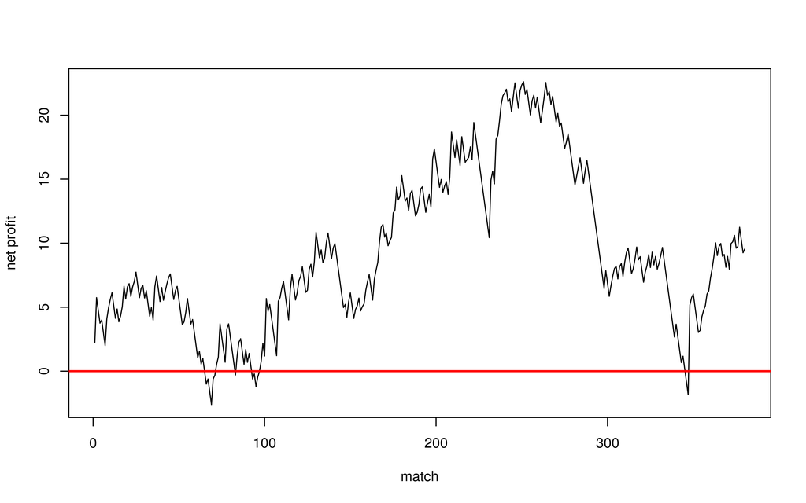

Then, we may compute the Brier score, a proper score function that measures the accuracy of probabilistic predictions, the mean squared error of the forecast, as:

$$\bar{b}=\frac{1}{n} \sum_{1=1}^{n}\sum_{i=1}^{3}(p_{i,n}-\delta_{i,n})^2,$$
where $p_{i,n}$ is the model probability for the $i$-th outcome in the $n$-th game, and $\delta_{i,n}$ the Kroenecker delta. The Brier score is bounded between 0 and 2, and the lower is this index the better is the prediction accuracy. Still, we compare the Brier score of our shots model with the Brier Score obtained under the double Poisson model: shots model yields a lower value (0.59 vs 0.62).

|  | Brier score |
| --- | --- |
| Double Poisson | 0.62 |
| Shots model | 0.59 |

# Conclusions

Including the shots in a scoring model:

- enriches the existing framework for modeling the scores
- slightly improves over the fit (looic)
- yields better predictions (Brier score).

Further work:

- correlation between scores/shots
- connect the shots model with *bookmakers* information, as partially done in Egidi, Pauli, and Torelli (2018).

Further R Code and analysis soon available at [www.leonardoegidi.com](https://www.leonardoegidi.com/) or contact me at legidi@units.it.

# Acknowledgments

Some of the code plots used in this presentation arise from the presentation *Hierarchical Bayesian Modeling of the English Premier League* given by Milad Kharratzadeh during the StanCon 2017 in New York.

# References

Baio, Gianluca, and Marta Blangiardo. 2010. “Bayesian Hierarchical Model for the Prediction of Football Results.” *Journal of Applied Statistics* 37 (2). Taylor & Francis: 253–64.

Egidi, Leonardo, Francesco Pauli, and Nicola Torelli. 2018. “Combining Historical Data and Bookmakers’ Odds in Modelling Football Scores.” *Statistical Modelling (to Appear). arXiv Preprint arXiv:1802.08848*.

Karlis, Dimitris, and Ioannis Ntzoufras. 2003. “Analysis of Sports Data by Using Bivariate Poisson Models.” *Journal of the Royal Statistical Society: Series D (the Statistician)* 52 (3). Wiley Online Library: 381–93.

Maher, Michael J. 1982. “Modelling Association Football Scores.” *Statistica Neerlandica* 36 (3). Wiley Online Library: 109–18.

Owen, Alun. 2011. “Dynamic Bayesian Forecasting Models of Football Match Outcomes with Estimation of the Evolution Variance Parameter.” *IMA Journal of Management Mathematics* 22 (2). Oxford University Press: 99–113.

Rue, Havard, and Oyvind Salvesen. 2000. “Prediction and Retrospective Analysis of Soccer Matches in a League.” *Journal of the Royal Statistical Society: Series D (the Statistician)* 49 (3). Wiley Online Library: 399–418.

Vehtari, Aki, Andrew Gelman, and Jonah Gabry. 2017. “Practical Bayesian Model Evaluation Using Leave-One-Out Cross-Validation and Waic.” *Statistics and Computing* 27 (5). Springer: 1413–32.